# chapter5

# Exercise 5: Dimensionality reduction techniques

For this exercise we will be looking at human development index (HDI) parameters presented by the United nations developments programme to assess the development of countries. Details of the project and explanations of the variables can be found [here](http://hdr.undp.org/en/content/human-development-index-hdi).

First, lets load the data:

```r
library(tidyverse)
#' read in modified file
human_data <- read.csv(here::here("data",
                                  "human.csv"),
                       row.names = 1)

#' glimpse
dplyr::glimpse(human_data)
```

```
## Rows: 155
## Columns: 8
## $ Edu.sec.prop <dbl> 1.0072389, 0.9968288, 0.9834369, 0.9886128, 0.9690608, 0.~
## $ Lbr_prop     <dbl> 0.8908297, 0.8189415, 0.8251001, 0.8840361, 0.8286119, 0.~
## $ Edu.Y        <dbl> 17.5, 20.2, 15.8, 18.7, 17.9, 16.5, 18.6, 16.5, 15.9, 19.~
## $ Life.ExpAB   <dbl> 81.6, 82.4, 83.0, 80.2, 81.6, 80.9, 80.9, 79.1, 82.0, 81.~
## $ GNI.pc       <int> 64992, 42261, 56431, 44025, 45435, 43919, 39568, 52947, 4~
## $ MMR          <int> 4, 6, 6, 5, 6, 7, 9, 28, 11, 8, 6, 4, 8, 4, 27, 2, 11, 6,~
## $ Adl_brthR    <dbl> 7.8, 12.1, 1.9, 5.1, 6.2, 3.8, 8.2, 31.0, 14.5, 25.3, 6.0~
## $ Prl_prc      <dbl> 39.6, 30.5, 28.5, 38.0, 36.9, 36.9, 19.9, 19.4, 28.2, 31.~
```

```r
#' summary
base::summary(human_data)
```

```
##   Edu.sec.prop       Lbr_prop          Edu.Y         Life.ExpAB
##  Min.   :0.1717   Min.   :0.1857   Min.   : 5.40   Min.   :49.00
##  1st Qu.:0.7264   1st Qu.:0.5984   1st Qu.:11.25   1st Qu.:66.30
##  Median :0.9375   Median :0.7535   Median :13.50   Median :74.20
##  Mean   :0.8529   Mean   :0.7074   Mean   :13.18   Mean   :71.65
##  3rd Qu.:0.9968   3rd Qu.:0.8535   3rd Qu.:15.20   3rd Qu.:77.25
##  Max.   :1.4967   Max.   :1.0380   Max.   :20.20   Max.   :83.50
##      GNI.pc            MMR           Adl_brthR         Prl_prc
##  Min.   :   581   Min.   :   1.0   Min.   :  0.60   Min.   : 0.00
##  1st Qu.:  4198   1st Qu.:  11.5   1st Qu.: 12.65   1st Qu.:12.40
##  Median : 12040   Median :  49.0   Median : 33.60   Median :19.30
##  Mean   : 17628   Mean   : 149.1   Mean   : 47.16   Mean   :20.91
##  3rd Qu.: 24512   3rd Qu.: 190.0   3rd Qu.: 71.95   3rd Qu.:27.95
##  Max.   :123124   Max.   :1100.0   Max.   :204.80   Max.   :57.50
```

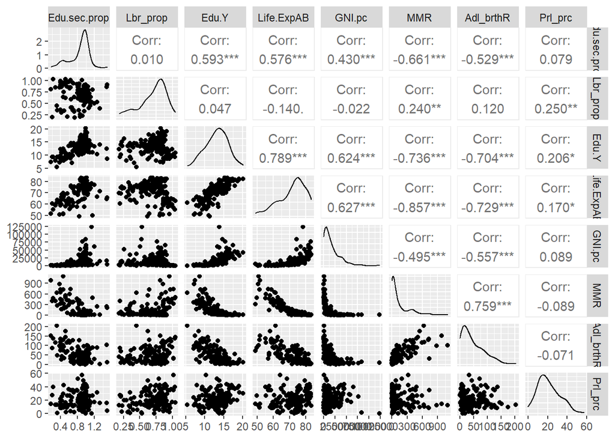

```r
#' pairs
GGally::ggpairs(human_data)
```

From the summary we can observe the large differences between countries, especially with GNI. Form the visualization we can further see that education and life expectancy at birth are strongly positively correlated with GNI, while both maternal mortality rate and adolescent birth rate and negatively correlated.

Next, we carry out principle component analysis (PCA)

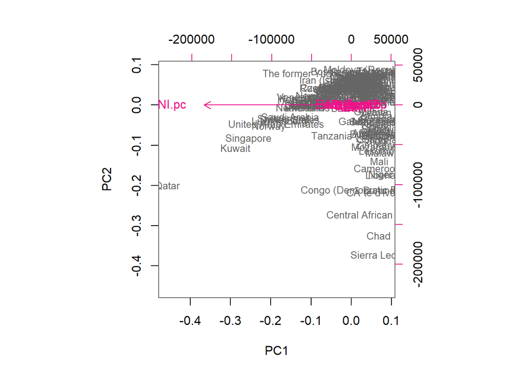

```r
#' PCA
pca <- stats::prcomp(human_data)
biplot(pca,
       choices = 1:2,
       cex = c(0.8, 1),
       col = c("grey40", "deeppink2"))
```

Looks like most countries are clumped together but a a handful can be seen branching away towards the bottom and left. These might be extreme entries that deviate drastically from average.